# stat_2

### Lachin Naghashyar - 98110179

## Part1 (EDA):

#### first let’s view the data in this file:

```r
data <- read.csv("lyon_housing.csv")
View(data)
summary(data)
```

```
##  date_transaction   type_purchase      type_property       rooms_count
##  Length:40516       Length:40516       Length:40516       Min.   :1.000
##  Class :character   Class :character   Class :character   1st Qu.:2.000
##  Mode  :character   Mode  :character   Mode  :character   Median :3.000
##                                                           Mean   :2.792
##                                                           3rd Qu.:4.000
##                                                           Max.   :6.000
##
##  surface_housing  surface_effective_usable surface_terrain   parkings_count
##  Min.   : 20.00   Min.   :  2.81           Min.   :  0.000   Min.   :0.0000
##  1st Qu.: 45.00   1st Qu.: 44.70           1st Qu.:  0.000   1st Qu.:0.0000
##  Median : 63.00   Median : 62.80           Median :  0.000   Median :1.0000
##  Mean   : 65.24   Mean   : 63.53           Mean   :  3.765   Mean   :0.5993
##  3rd Qu.: 80.00   3rd Qu.: 78.11           3rd Qu.:  0.000   3rd Qu.:1.0000
##  Max.   :300.00   Max.   :270.67           Max.   :944.000   Max.   :3.0000
##                   NA's   :14491
##      price           address            district            latitude
##  Min.   :  24000   Length:40516       Length:40516       Min.   :45.72
##  1st Qu.: 155273   Class :character   Class :character   1st Qu.:45.75
##  Median : 220000   Mode  :character   Mode  :character   Median :45.76
##  Mean   : 255759                                         Mean   :45.76
##  3rd Qu.: 309000                                         3rd Qu.:45.77
##  Max.   :2780000                                         Max.   :45.81
##                                                          NA's   :143
##    longitude     date_construction
##  Min.   :4.773   Length:40516
##  1st Qu.:4.831   Class :character
##  Median :4.854   Mode  :character
##  Mean   :4.852
##  3rd Qu.:4.876
##  Max.   :4.920
##  NA's   :143
```

### NA and null values

#### Let’s see how many of these values are NA.

```r
print(paste("total NA cells of: ", sum(is.na(data))))
```

```
## [1] "total NA cells of:  14777"
```

```r
colSums(is.na(data))
```

```
##         date_transaction            type_purchase            type_property
##                        0                        0                        0
##              rooms_count          surface_housing surface_effective_usable
##                        0                        0                    14491
##          surface_terrain           parkings_count                    price
##                        0                        0                        0
##                  address                 district                 latitude
##                        0                        0                      143
##                longitude        date_construction
##                      143                        0
```

#### As we can see, NA values belong to columns surface_effective_usable, latitude and longitude. Also, we don’t have null values:

```r
print(paste("total null cells of: ", sum(is.null(data))))
```

```
## [1] "total null cells of:  0"
```

#### latitude and longitude have the same number of NAs, lets see if they belong the the same rows:

```r
if (which(is.na(data$latitude)) == which(is.na(data$longitude))){
  print("they belong to same rows")
} else {
  print("they don't belong to same rows")
}
```

```
## [1] "they belong to same rows"
```

#### for the NA values in surface_effective_usable, we use the corresponding value in surface_housing column. The reason for that is that surface_effective_usable and c have almost the same values and are really close to each other. (We can also drop surface_effective_usable column).

```r
data$surface_effective_usable <- ifelse(is.na(data$surface_effective_usable), data$surface_housing, data$surface_effective_usable)
```

#### Also delete the 143 (certainly a small number compairng to 40,516 rows that we have) rows which had NA values.

```r
data = data[complete.cases(data), ]
print(paste("total NA cells of: ", sum(is.na(data))))
```

```
## [1] "total NA cells of:  0"
```

### Data types and range of columns

#### Let’s check the data type and range of each column:

```r
sapply(data, class)
```

```
##         date_transaction            type_purchase            type_property
##              "character"              "character"              "character"
##              rooms_count          surface_housing surface_effective_usable
##                "integer"                "integer"                "numeric"
##          surface_terrain           parkings_count                    price
##                "integer"                "integer"                "numeric"
##                  address                 district                 latitude
##              "character"              "character"                "numeric"
##                longitude        date_construction
##                "numeric"              "character"
```

```r
data.frame(min=sapply(data,min),max=sapply(data,max))
```

```
##                                              min              max
## date_transaction                        16/07/01         21/06/30
## type_purchase                             ancien             VEFA
## type_property                        appartement           maison
## rooms_count                                    1                6
## surface_housing                               20              300
## surface_effective_usable                    2.81              286
## surface_terrain                                0              944
## parkings_count                                 0                3
## price                                      24000          2780000
## address                                          99 RUE TETE D'OR
## district                 Lyon 1er Arrondissement     Villeurbanne
## latitude                               45.722048        45.805458
## longitude                               4.773162         4.920161
## date_construction                 00/01/08 11:38   99/12/17 11:38
```

#### we can see that date_construction includes the unecessary value of 11:38. and we can drop that since the hour of construction is not important. Also note that time is only in two forms of 00:00 and 11:38.

```r
data$date_construction <- as.Date(data$date_construction, format = '%y/%m/%d')
```

#### Also I changed the data format in data_transaction in the same way.

```r
data$date_transaction <- as.Date(data$date_transaction, format = '%y/%m/%d')
```

```r
data <- subset(data, !(data$date_transaction > Sys.Date() & data$type_purchase != "VEFA"))
```

#### we should also delete the ancien ones which their construction data is after their transaction data.

```r
data <- subset(data, !(data$date_transaction - data$date_construction < 0 & data$type_purchase != "VEFA"))
```

### Distribution of each column

#### Now let’s plot the distribution of each column in this data frame separately.

```r
# my_plots <- lapply(names(data), function(var_x){
#   p <- ggplot(data) + aes_string(var_x)
#
#   if(is.numeric(data[[var_x]])) {
#     p <- p + geom_density()
#
#   } else {
#     p <- p + geom_bar()
#   }
#
# })
# plot_grid(plotlist = my_plots)
```

#### the code above might take some time(~2 mintues) to run so I am going to only plot the ones that I find important here.

#### Type of puchase seems to be more ancien than VEFA:

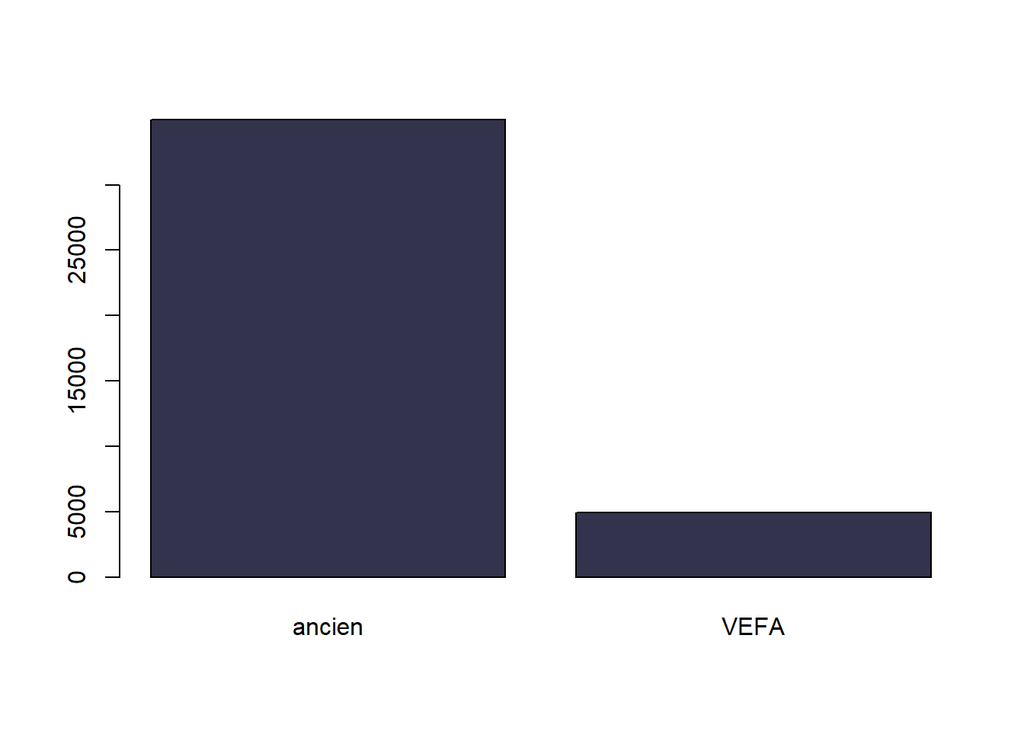

```r
barplot(table(data$type_purchase), col = rgb(0.2, 0.2, 0.3))
```

#### Also Appartements are by far the popular house type compared to maisons.

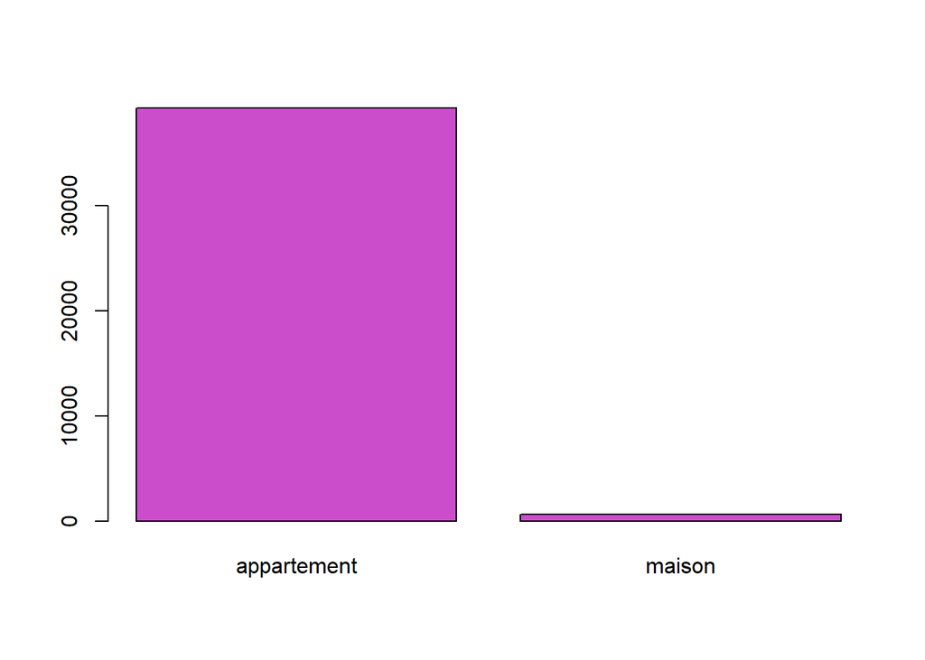

```r
barplot(table(data$type_property), col = rgb(0.8, 0.3, 0.8))
```

#### For the room count, 3 bedrooms is the most popular one. Next are the houses with 2, 4, 1, 5 and 6 bedrooms respectively.

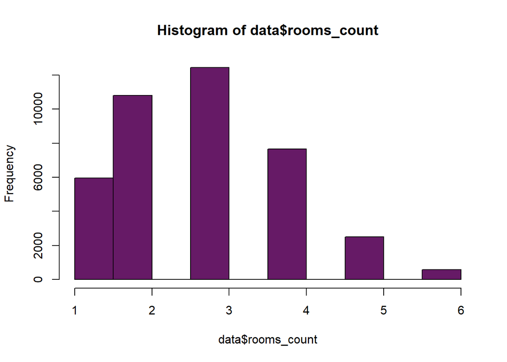

```r
hist(data$rooms_count, col = rgb(0.4, 0.1, 0.4))
```

#### Also looking at surface_housing and surface_effective_useable, they almost have the same distribution. Let’s compute their correlation:

```r
cor(data$surface_housing, data$surface_effective_usable)
```

```
## [1] 0.9765241
```

#### Hence they are almost the same and one option is to eliminate one of them from the data frame.

```r
data <- data %>% select(-surface_effective_usable)
```

#### Looking at the surface trrain, it has an odd distribution:

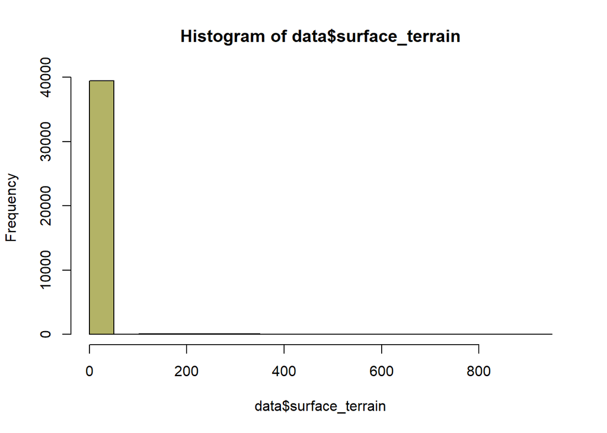

```r
hist(data$surface_terrain, col = rgb(0.7, 0.7, 0.4))
```

#### Almost all of its values are zero. Let’s see the percentage of zeros:

```r
percentage = colSums(data==0)/nrow(data)*100
percentage
```

```
##  date_transaction     type_purchase     type_property       rooms_count
##           0.00000           0.00000           0.00000           0.00000
##   surface_housing   surface_terrain    parkings_count             price
##           0.00000          98.66326          45.62181           0.00000
##           address          district          latitude         longitude
##           0.00000           0.00000           0.00000           0.00000
## date_construction
##           0.00000
```

#### It is more than 98 percent so maybe we should drop this column.

```r
data = subset(data, select = -surface_terrain)
```

#### Most of the houses have 1 parking or no parking at all.

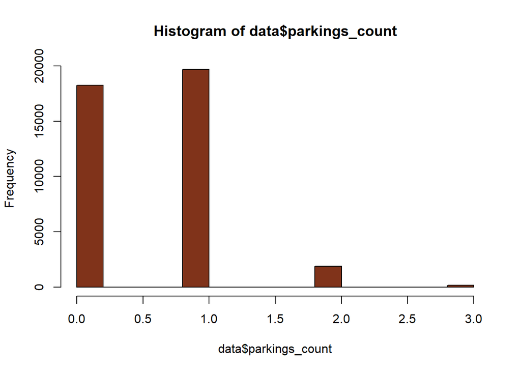

```r
hist(data$parkings_count, col = rgb(0.5, 0.2, 0.1))
```

#### Another important factor is house price:

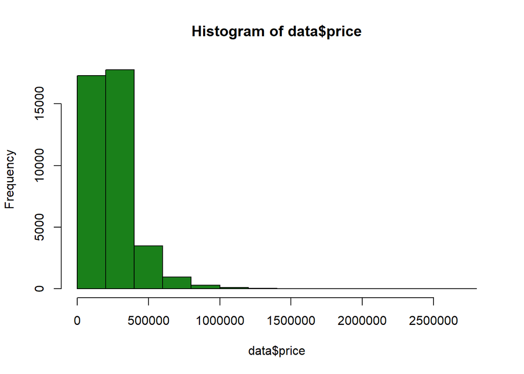

```r
hist(data$price, col = rgb(0.1, 0.5, 0.1))
```

#### Most of the houses have a price around 250000.

#### For last one, I plot the distribution of districts:

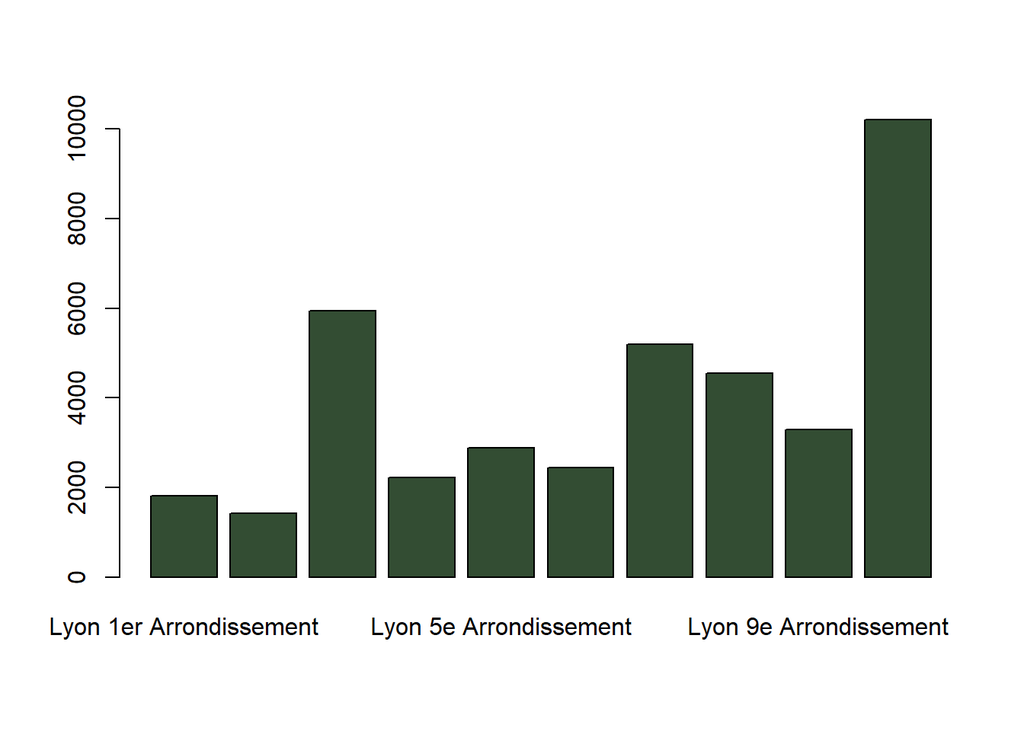

```r
barplot(table(data$district), col = rgb(0.2, 0.3, 0.2))
```

#### As you can see, the last district contains almost more then twice the number of houses compared to other districts.

### Add new columns

```r
data$property_age <- data$date_transaction - data$date_construction
```

### Correlation between columns

#### compute the correlation between columns using rcorr function from Hmisc package.

```r
res <- rcorr(as.matrix(data[, c(4, 5, 6, 7)]))
res
```

```
##                 rooms_count surface_housing parkings_count price
## rooms_count            1.00            0.84           0.27  0.56
## surface_housing        0.84            1.00           0.22  0.75
## parkings_count         0.27            0.22           1.00  0.19
## price                  0.56            0.75           0.19  1.00
##
## n= 39948
##
##
## P
##                 rooms_count surface_housing parkings_count price
## rooms_count                  0               0              0
## surface_housing  0                           0              0
## parkings_count   0           0                              0
## price            0           0               0
```

#### we can see that there is a high (reasonable) correlation between surface_housing and rooms_count (0.84). As well as a high correlation (0.75) between surface_housing and price.

#### the plot of the correaltions is as follows:

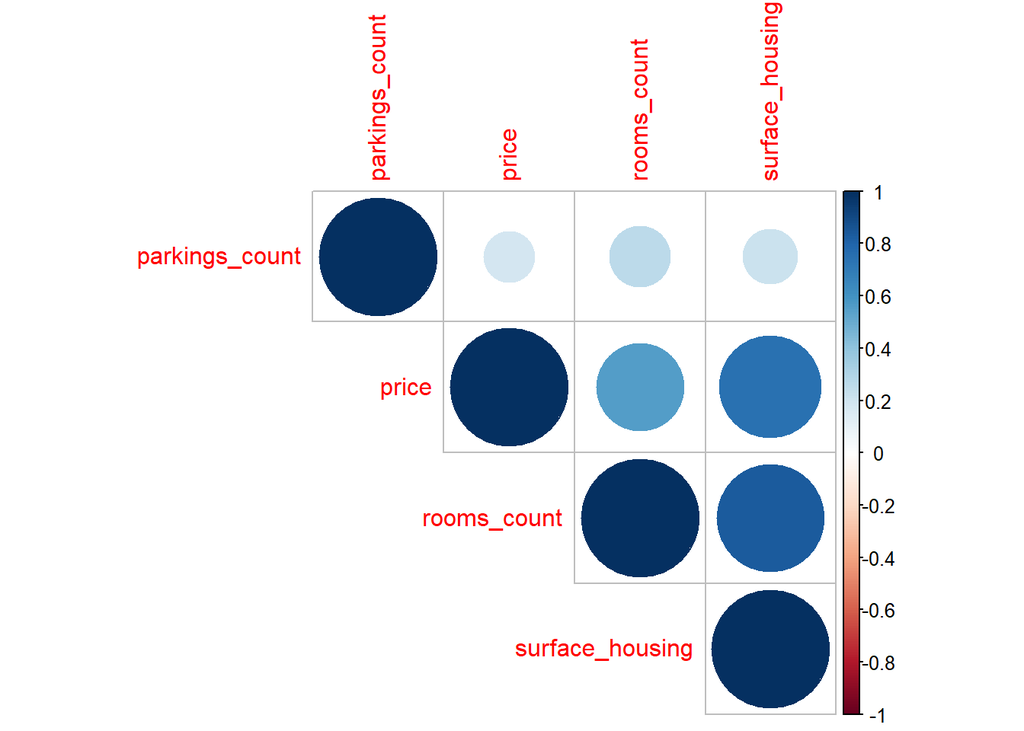

```r
corrplot(res$r, type="upper", order="hclust",
          sig.level = 0.01, insig = "blank")
```

#### we can also plot a chart for their correlation

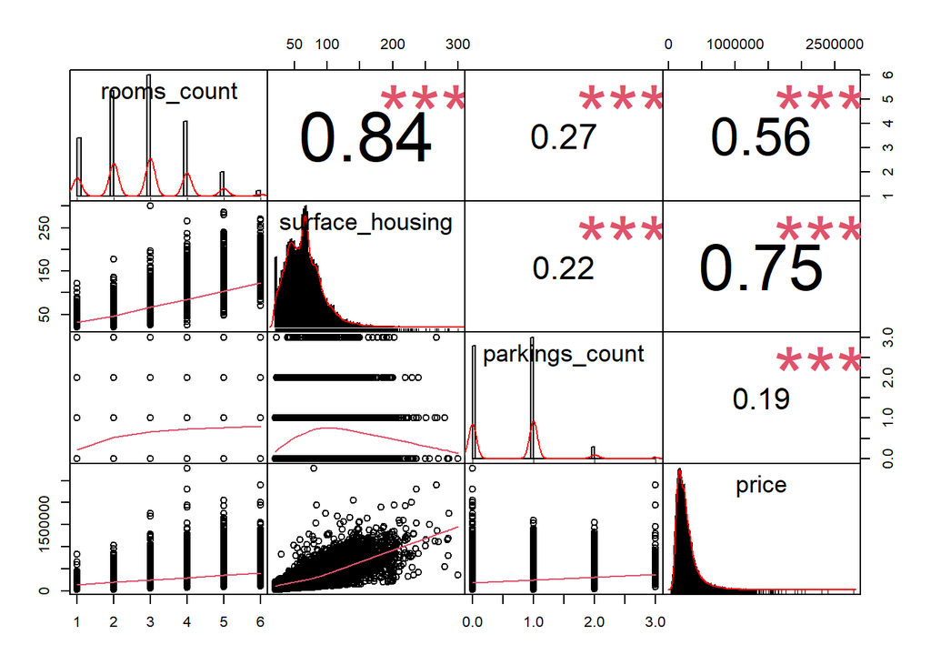

```r
my_data <- data[, c(4,5,6,7)]
chart.Correlation(my_data, histogram=TRUE, pch=19)
```

### Use the data from subway stations file

```r
dfs <- fromJSON('station_coordinates.json')
dfA <- dfs$A
dfB <- dfs$B
dfC <- dfs$D
dfD <- dfs$D
dfT1 <- dfs$T1
dfT2 <- dfs$T2
dfT3 <- dfs$T3
dfT4 <- dfs$T4
dfT5 <- dfs$T5
dfT6 <- dfs$T6
dfT7 <- dfs$T7

stations = c()
lat = c()
long = c()
stations_list <- list(dfA, dfB, dfC, dfD, dfT1, dfT2, dfT3, dfT4, dfT5, dfT6, dfT7)
for (s in stations_list){
  stations = c(stations, s$stations)
  lat = c(lat, s$latitudes)
  long = c(long, s$longitudes)
}
```

```r
min_distanc <-function(i){
   stas = c()
  for (j in (1:length(stations))){
    distance = distm(c(long[j], lat[j]), c(data[['longitude']][i], data[['latitude']][i]), fun = distHaversine)
    stas = c(stas, distance)
  }
   return(stas)
}
```

## Part 2

### Check if the price and area have a normal distribution

#### We plot the histogram of price earlier and it seemed that it might have a normal distribution. Let’s also take a look at its density function too.

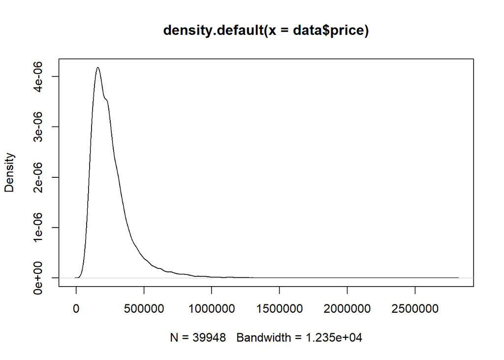

```r
plot(density(data$price))
```

#### To check if it has a normal distribution, we can perform the shapiro test on it. Take the null hypothesis to be that this distribution is normal. Hence, if test is significant, it is not normal. First, take a sample of size 50 and perform the test on them.

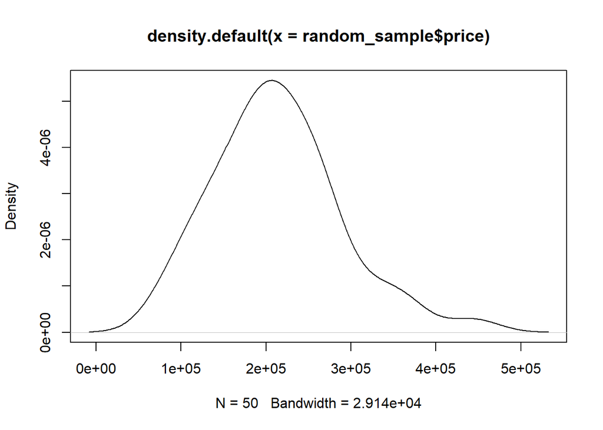

```r
set.seed(1000)
random_sample <- dplyr::sample_n(data, 50)
plot(density(random_sample$price))
```

```r
shapiro.test(random_sample$price)
```

```
##
##  Shapiro-Wilk normality test
##
## data:  random_sample$price
## W = 0.96998, p-value = 0.231
```

#### Let’s do the same for suface area and take a look at its density

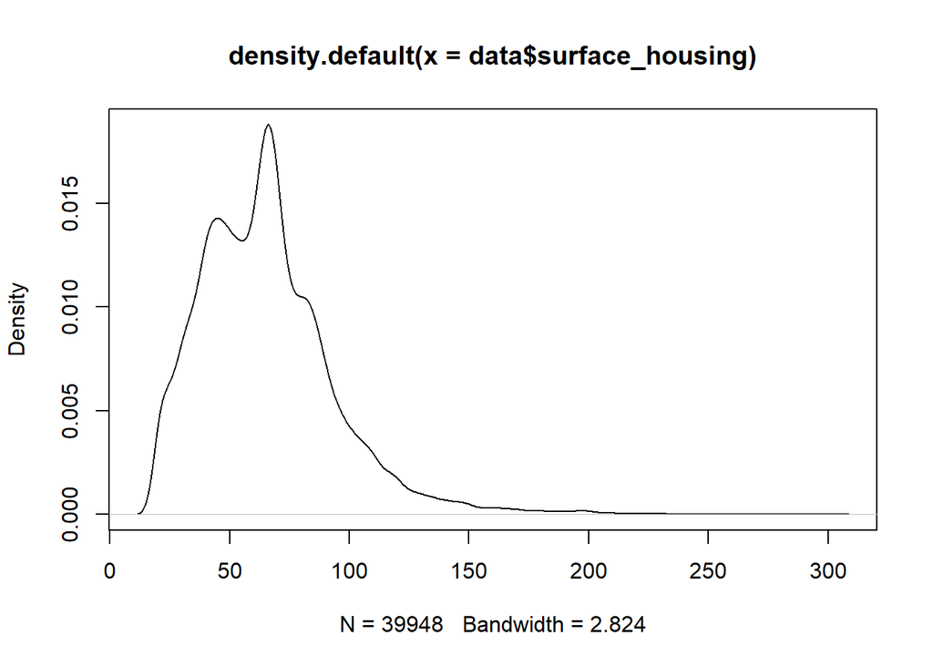

```r
plot(density(data$surface_housing))
```

#### Similarly, we perform the shapiro test on it. Take the null hypothesis to be that this distribution is normal.

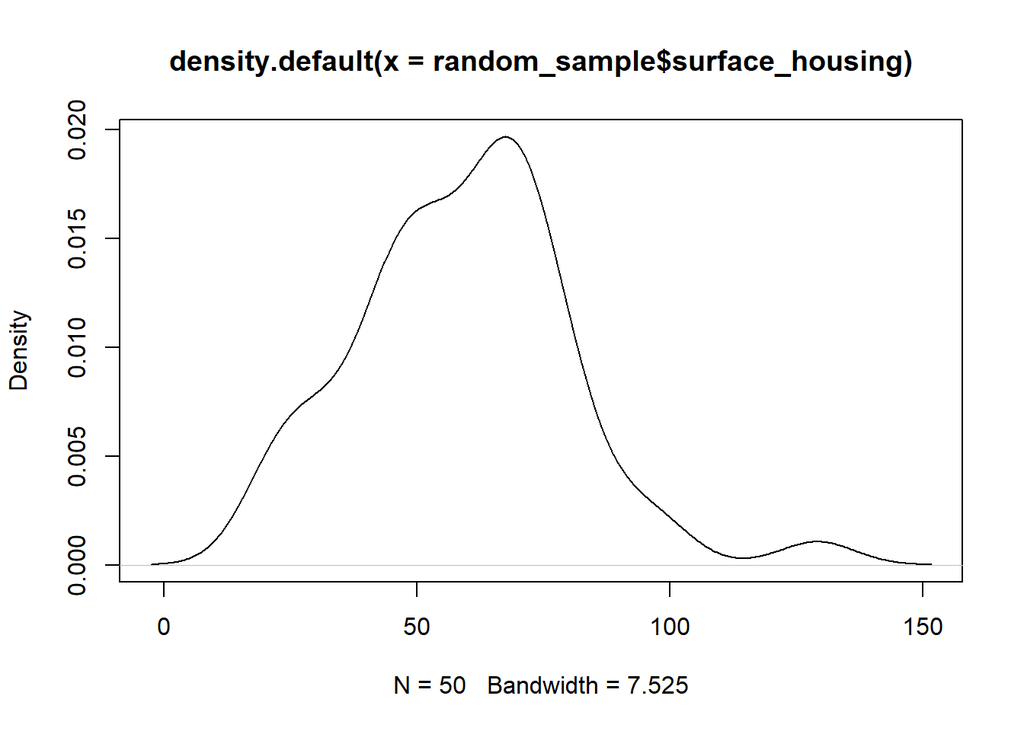

```r
set.seed(1000)
random_sample <- dplyr::sample_n(data, 50)
plot(density(random_sample$surface_housing))
```

```r
shapiro.test(random_sample$surface_housing)
```

```
##
##  Shapiro-Wilk normality test
##
## data:  random_sample$surface_housing
## W = 0.96572, p-value = 0.1542
```

#### The corresponging p-value is higher than 0.05, we can not reject the null hyphothesis. Meaning we can not say area’s distribution is not normal.

### Check the correlation between price and surface housing.

#### We do this first by doing a regression on price and surface_housing

```r
reg = lm(price ~ surface_housing, data)
summary(reg)
```

```
##
## Call:
## lm(formula = price ~ surface_housing, data = data)
##
## Residuals:
##     Min      1Q  Median      3Q     Max
## -854382  -57289   -1824   49988 2463407
##
## Coefficients:
##                  Estimate Std. Error t value Pr(>|t|)
## (Intercept)     -11180.11    1292.88  -8.647   <2e-16 ***
## surface_housing   4097.16      18.18 225.325   <2e-16 ***
## ---
## Signif. codes:  0 '***' 0.001 '**' 0.01 '*' 0.05 '.' 0.1 ' ' 1
##
## Residual standard error: 102700 on 39946 degrees of freedom
## Multiple R-squared:  0.5597, Adjusted R-squared:  0.5597
## F-statistic: 5.077e+04 on 1 and 39946 DF,  p-value: < 2.2e-16
```

#### we can see that the slope is around 4097 and standard deviation is 18.18.

#### Knowing that $ I = [- 1.96 , + 1.96 ]$, we can substitue miu and sigma there and see that $ I = [4061 ,4132] $. Clearly, zero doesn’t fall in to this interval and we can be sure that they have a linear relation. Meaning a larger house, costs more (as expected).

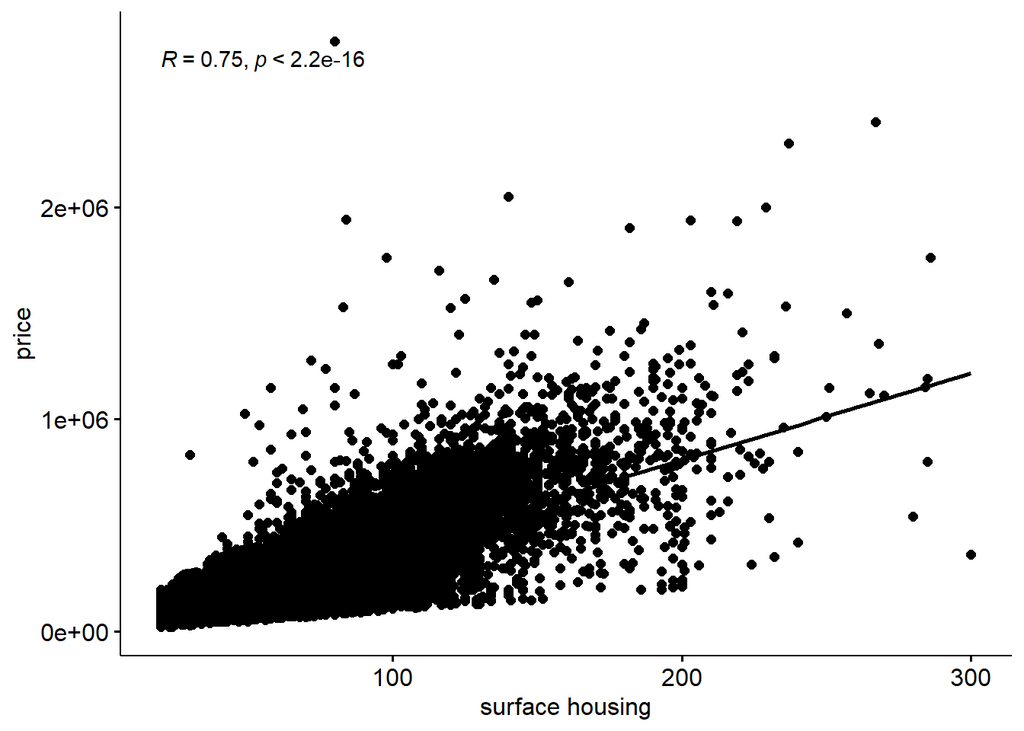

```r
ggscatter(data, x = "surface_housing", y = "price",
          add = "reg.line", conf.int = TRUE,
          cor.coef = TRUE, cor.method = "pearson",
          xlab = "surface housing", ylab = "price")
```

## Part 3: Estimation

#### The property that we would like to buy should be close to university, as cheap as possible , as large as possible, with at least 3 rooms and one parking. First we see the location of the university in map :

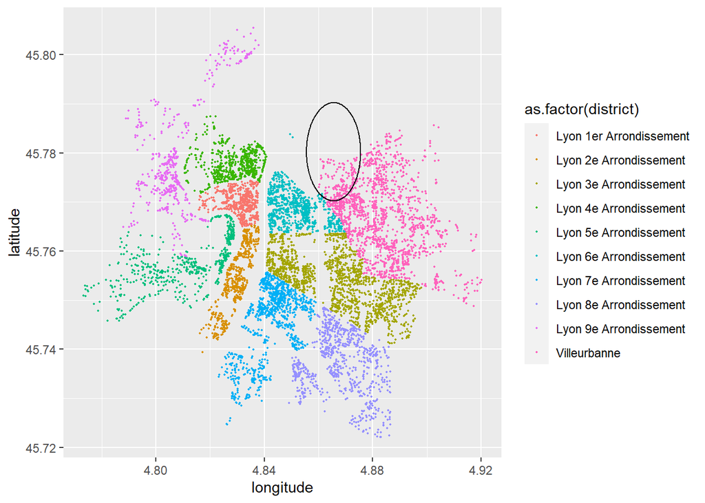

```r
lat = 45.780234113880425
l = 4.865561717882041
ggplot() +geom_point( data=data, aes(y=latitude, x=longitude, color = as.factor(district)), size = 0.4)+geom_circle(aes(x0 = l, y0 = lat, r = 0.01))
```

#### If we want the property to be close to university, we should either buy it in Villeurbanne or district 6.

```r
houses <-subset(data,(district == "Villeurbanne" | district=="Lyon 6e Arrondissement")  & (rooms_count > 2) & (parkings_count > 0))
```

#### Now that we have applied filter for number of rooms and parking and distance, we should consider price and size. For this, let’s first normalize the area and the price of the filtered houses:

```r
normal_prices=houses$price/mean(houses$price)
normal_area=houses$surface_housing/mean(houses$surface_housing)
```

#### Define a score function for each house as $10 \times area - 5 \times price$. Now we compute the score of each filtered house :

```r
score <-10*normal_area-5*normal_prices
i=which(score==max(score))
print(paste(houses$longitude[i], houses$latitude[i]))
```

```
## [1] "4.880895 45.764189"
```

#### Finally, we select the house with the maximum score and choose an interval around it as our target territory for buying a house

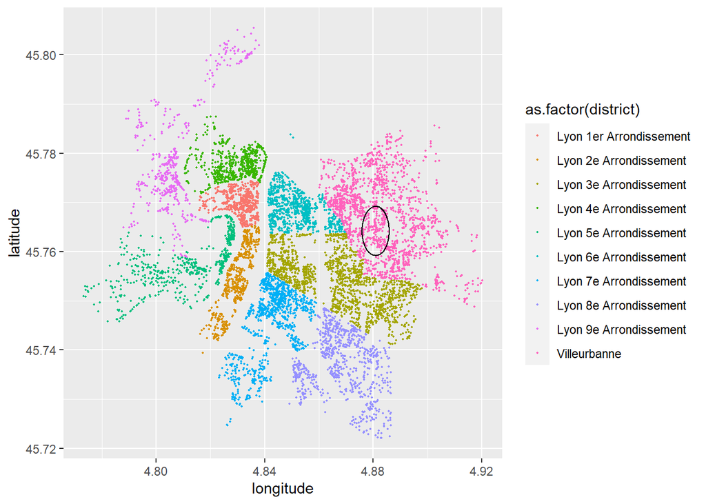

```r
i=which(score==max(score))
long=houses$longitude[i]
lat=houses$latitude[i]
ggplot() +geom_point( data=data, aes(y=latitude, x=longitude, color = as.factor(district)), size = 0.4)+geom_circle(aes(x0 = long, y0 = lat, r = 0.005))
```